# Project: Investigate a Dataset (Show and No Show of Patients for Medical Appointments)

- Introduction
- Data Wrangling
- Exploratory Data Analysis
- Conclusions

## Introduction

This dataset collects information from 100k medical appointments in Brazil and is focused on the question of whether or not patients show up for their appointment. A number of characteristics about the patient are included in each row. Our Task in here to import the data, cleand and analyze in order to get some facts about Show and No Show of Medical Appointment.

##### Context

A person makes a doctor appointment, receives all the instructions and no-show. Who to blame? If this help you studying or working, please don´t forget to upvote :). Reference to Joni Hoppen and Aquarela Advanced Analytics Aquarela.

##### Content

110.527 medical appointments its 14 associated variables (characteristics). The most important one if the patient show-up or no-show to the appointment. Variable names are self-explanatory, if you have doubts, just let me know!

scholarship variable means this concept = https://en.wikipedia.org/wiki/Bolsa_Fam%C3%ADlia

14 variables

##### Data Dictionary:

- PatientId: Identification of a patient
- AppointmentID: Identification of each appointment
- Gender:Male or Female . Female is the greater proportion, woman takes way more care of they health in comparison to man.
- Age: How old is the patient.
- AppointmentDay: In which Day the patient schedule a date.
- ScheduledDay: tells us on what day the patient set up their appointment.
- Neighborhood’ indicates the location of the hospital.
- Neighbourhood: Where the appointment takes place.
- Scholarship:True of False . Observation, this is a broad topic, consider reading this article https://en.wikipedia.org/wiki/Bolsa_Fam%C3%ADlia
- Hipertension: 0 or 1.
- Diabetes: 0 or 1.
- Alcoholism: o or 1.
- Handcap: The Handicap status from 0 to 4.
- SMS_received: 1 or more messages sent to the patient.
- No-show: True or False.

##### Inspiration:

What if that possible to predict someone to no-show an appointment?

##### Scope:

Our scope in this investigation is to Assess, Clean, Investigate The Data and retreive answers for below questions:

- Research Question 1 (in General, regardless all other values, plot the percentage of Show and No-Show frequency!)
- Research Question 2 (How The Gender Type impacts the Show and No Show Frequency and Percentage!)
- Research Question3 (How The Scheduled Weekday impacts the Show and No Show Frequency and Percentage!)
- Research Question 4 (How the Days difference between Appointment Day and Scheduled Day impacts the Show and No Show Frequency and Percentage!)
- Research Question 5 (Highest City has the Most Show!)
- Research Question 6 (How Scholarship impacts the Show and No Show Frequency and Percentage!)
- Research Question 7 (How Diseases impacts the Show and No Show Frequency and Percentage!)
- Research Question 8 (Does Handicap Grades affects the Show status!)
- Research Question 9 (How Alcoholism Status impacts the Show and No Show Frequency and Percentage!)
- Research Question 10 (Does Sending SMS to Patients affects the Show status!)
- Research Question 11 (Average Age of Show and No Show!)

```python
# Import needed Libraries
import pandas as pd
import datetime
import numpy as np
import matplotlib.pyplot as plt
from matplotlib import pyplot
import seaborn as sns
%matplotlib inline
```

## Data Wrangling

### General Properties

Data set File been downloaded fro Kaggle. So will import into Pandas Dataframe.

```python
# Loading our Dataset from CSV file
df=pd.read_csv('noshow.csv')
```

```python
df.head()
```

|  | PatientId | AppointmentID | Gender | ScheduledDay | AppointmentDay | Age | Neighbourhood | Scholarship | Hipertension | Diabetes | Alcoholism | Handcap | SMS_received | No-show |
| --- | --- | --- | --- | --- | --- | --- | --- | --- | --- | --- | --- | --- | --- | --- |
| 0 | 2.987250e+13 | 5642903 | F | 2016-04-29T18:38:08Z | 2016-04-29T00:00:00Z | 62 | JARDIM DA PENHA | 0 | 1 | 0 | 0 | 0 | 0 | No |
| 1 | 5.589978e+14 | 5642503 | M | 2016-04-29T16:08:27Z | 2016-04-29T00:00:00Z | 56 | JARDIM DA PENHA | 0 | 0 | 0 | 0 | 0 | 0 | No |
| 2 | 4.262962e+12 | 5642549 | F | 2016-04-29T16:19:04Z | 2016-04-29T00:00:00Z | 62 | MATA DA PRAIA | 0 | 0 | 0 | 0 | 0 | 0 | No |
| 3 | 8.679512e+11 | 5642828 | F | 2016-04-29T17:29:31Z | 2016-04-29T00:00:00Z | 8 | PONTAL DE CAMBURI | 0 | 0 | 0 | 0 | 0 | 0 | No |
| 4 | 8.841186e+12 | 5642494 | F | 2016-04-29T16:07:23Z | 2016-04-29T00:00:00Z | 56 | JARDIM DA PENHA | 0 | 1 | 1 | 0 | 0 | 0 | No |

```python
#Check for Null Values.
df.isnull().sum()
```

```
PatientId         0
AppointmentID     0
Gender            0
ScheduledDay      0
AppointmentDay    0
Age               0
Neighbourhood     0
Scholarship       0
Hipertension      0
Diabetes          0
Alcoholism        0
Handcap           0
SMS_received      0
No-show           0
dtype: int64
```

```python
df.nunique()
```

```
PatientId          62299
AppointmentID     110527
Gender                 2
ScheduledDay      103549
AppointmentDay        27
Age                  104
Neighbourhood         81
Scholarship            2
Hipertension           2
Diabetes               2
Alcoholism             2
Handcap                5
SMS_received           2
No-show                2
dtype: int64
```

```python
df.info()
```

```
<class 'pandas.core.frame.DataFrame'>
RangeIndex: 110527 entries, 0 to 110526
Data columns (total 14 columns):
 #   Column          Non-Null Count   Dtype
---  ------          --------------   -----
 0   PatientId       110527 non-null  float64
 1   AppointmentID   110527 non-null  int64
 2   Gender          110527 non-null  object
 3   ScheduledDay    110527 non-null  object
 4   AppointmentDay  110527 non-null  object
 5   Age             110527 non-null  int64
 6   Neighbourhood   110527 non-null  object
 7   Scholarship     110527 non-null  int64
 8   Hipertension    110527 non-null  int64
 9   Diabetes        110527 non-null  int64
 10  Alcoholism      110527 non-null  int64
 11  Handcap         110527 non-null  int64
 12  SMS_received    110527 non-null  int64
 13  No-show         110527 non-null  object
dtypes: float64(1), int64(8), object(5)
memory usage: 11.8+ MB
```

### Quick Look and Summary for the Provided Data Set

Now let's dig deeper into our dataset to identify the needed data cleaning before analysis and visualization.

### Data Cleaning (Start with above notes and dig deeper into provided data set details)

#### Take a copy of the cleaned dataset before doing our data cleaning:

```python
#Copy Priginl Dataframe
df_c=df.copy()
```

#### Change PatientId and AppointmentID to String

```python
#change PatientId to int64 then String in order to remove decimal zeros
df_c['PatientId']=df_c['PatientId'].astype('int64').astype(str)
```

```python
df_c['AppointmentID']=df_c['AppointmentID'].astype(str)
```

#### Change AppointmentDay and ScheduledDay from String to Datetime data type

```python
df_c['ScheduledDay']=pd.to_datetime(df_c['ScheduledDay'])
```

```python
df_c['AppointmentDay']=pd.to_datetime(df_c['AppointmentDay'])
```

> Now let's check changes have been done above.

```python
df_c.info()
```

```
<class 'pandas.core.frame.DataFrame'>
RangeIndex: 110527 entries, 0 to 110526
Data columns (total 14 columns):
 #   Column          Non-Null Count   Dtype
---  ------          --------------   -----
 0   PatientId       110527 non-null  object
 1   AppointmentID   110527 non-null  object
 2   Gender          110527 non-null  object
 3   ScheduledDay    110527 non-null  datetime64[ns, UTC]
 4   AppointmentDay  110527 non-null  datetime64[ns, UTC]
 5   Age             110527 non-null  int64
 6   Neighbourhood   110527 non-null  object
 7   Scholarship     110527 non-null  int64
 8   Hipertension    110527 non-null  int64
 9   Diabetes        110527 non-null  int64
 10  Alcoholism      110527 non-null  int64
 11  Handcap         110527 non-null  int64
 12  SMS_received    110527 non-null  int64
 13  No-show         110527 non-null  object
dtypes: datetime64[ns, UTC](2), int64(7), object(5)
memory usage: 11.8+ MB
```

> Great!! let's Dig Deeper and proceed for further inspection.

### More Dataset inspection and cleaning

#### ScheduledDay and AppointmentDay:

For the ScheduledDay and AppointmentDay, We could generate more data from the datetime for more data investigation as below:

- ScheduledDay date
- ScheduledDay day of the week
- AppointmentDay date
- The period between AppointmentDay and ScheduledDay and how it is affecting No-show status

```python
#generate Miscalleneous data from ScheduledDay and AppointmentDay datetime data
sched_date = pd.to_datetime(df_c['ScheduledDay']).dt.date
df_c.insert(3, 'schedule_date', sched_date)

app_date = pd.to_datetime(df_c['AppointmentDay']).dt.date
df_c.insert(3, 'appointment_date', app_date)

sched_weekday = pd.to_datetime(df_c['ScheduledDay']).dt.day_name()
df_c.insert(3, 'schedule_weekday', sched_weekday)
```

Calculate Difference Days between AppointmentDay and ScheduledDay to investigate how that will affect No-Show status.

```python
#Calculate Difference Days
date_gap= df_c['appointment_date']-df_c['schedule_date']
df_c.insert(8, 'Days_diff', date_gap)
```

```python
#Look at the data
df_c.Days_diff.value_counts().sort_values(ascending=True)
```

```
125 days        1
123 days        1
101 days        1
82 days         1
139 days        1
            ...
7 days       4906
1 days       5213
4 days       5290
2 days       6725
0 days      38563
Name: Days_diff, Length: 131, dtype: int64
```

```python
df_c['Days_diff'] = pd.to_numeric(df_c['Days_diff'].dt.days, downcast='integer')
df_c[df_c.Days_diff <0]
```

|  | PatientId | AppointmentID | Gender | schedule_weekday | appointment_date | schedule_date | ScheduledDay | AppointmentDay | Days_diff | Age | Neighbourhood | Scholarship | Hipertension | Diabetes | Alcoholism | Handcap | SMS_received | No-show |
| --- | --- | --- | --- | --- | --- | --- | --- | --- | --- | --- | --- | --- | --- | --- | --- | --- | --- | --- |
| 27033 | 7839272661752 | 5679978 | M | Tuesday | 2016-05-09 | 2016-05-10 | 2016-05-10 10:51:53+00:00 | 2016-05-09 00:00:00+00:00 | -1 | 38 | RESISTÊNCIA | 0 | 0 | 0 | 0 | 1 | 0 | Yes |
| 55226 | 7896293967868 | 5715660 | F | Wednesday | 2016-05-17 | 2016-05-18 | 2016-05-18 14:50:41+00:00 | 2016-05-17 00:00:00+00:00 | -1 | 19 | SANTO ANTÔNIO | 0 | 0 | 0 | 0 | 1 | 0 | Yes |
| 64175 | 24252258389979 | 5664962 | F | Thursday | 2016-05-04 | 2016-05-05 | 2016-05-05 13:43:58+00:00 | 2016-05-04 00:00:00+00:00 | -1 | 22 | CONSOLAÇÃO | 0 | 0 | 0 | 0 | 0 | 0 | Yes |
| 71533 | 998231581612122 | 5686628 | F | Wednesday | 2016-05-05 | 2016-05-11 | 2016-05-11 13:49:20+00:00 | 2016-05-05 00:00:00+00:00 | -6 | 81 | SANTO ANTÔNIO | 0 | 0 | 0 | 0 | 0 | 0 | Yes |
| 72362 | 3787481966821 | 5655637 | M | Wednesday | 2016-05-03 | 2016-05-04 | 2016-05-04 06:50:57+00:00 | 2016-05-03 00:00:00+00:00 | -1 | 7 | TABUAZEIRO | 0 | 0 | 0 | 0 | 0 | 0 | Yes |

> We have some negative values which is not logic that the Scheduled Day before Appointment Day. So will drop these values.

```python
df_c=df_c[(df_c.Days_diff >=0)]
df_c.Days_diff.value_counts().sort_values(ascending=True)
```

```
127        1
117        1
125        1
132        1
126        1
       ...
7       4906
1       5213
4       5290
2       6725
0      38563
Name: Days_diff, Length: 129, dtype: int64
```

Now we don't need the ScheduledDay, AppointmentDay and appointment_date as we have generated other needed data. so will dop these 3 columns.

```python
df_c.drop('ScheduledDay', axis=1, inplace=True)
df_c.drop('AppointmentDay', axis=1, inplace=True)
df_c.drop('appointment_date', axis=1, inplace=True)
```

### Age:

will check how Age data distributed and if it needs any cleaning

```
-1         1
 0      3539
 1      2273
 2      1618
 3      1513
        ...
 98        6
 99        1
 100       4
 102       2
 115       5
Name: Age, Length: 104, dtype: int64
```

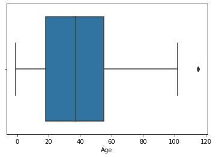

```python
# Check outliers using box plot
print(df_c['Age'].value_counts().sort_index())
sns.boxplot(x=df_c['Age'])
plt.show()
```

As appeared above, we have age values =-1 and other values more than 100 years old. The -1 Age value probably for pregnant mothers and records for their childs, but anway, we will remove these values as we are not sure the concept of it. on other hand,there are 5 records for Age about 115 Years old, it is a bit confusing if it is applicable or not. For me, if I could last that long, I wouldn't have to see the doctor anyway as I won't need to 💪. so let's have a close look for prsons more than 100 Years.

```python
df_c[df_c.Age >=100]
```

|  | PatientId | AppointmentID | Gender | schedule_weekday | schedule_date | Days_diff | Age | Neighbourhood | Scholarship | Hipertension | Diabetes | Alcoholism | Handcap | SMS_received | No-show |
| --- | --- | --- | --- | --- | --- | --- | --- | --- | --- | --- | --- | --- | --- | --- | --- |
| 58014 | 976294799775439 | 5651757 | F | Tuesday | 2016-05-03 | 0 | 102 | CONQUISTA | 0 | 0 | 0 | 0 | 0 | 0 | No |
| 63912 | 31963211613981 | 5700278 | F | Monday | 2016-05-16 | 3 | 115 | ANDORINHAS | 0 | 0 | 0 | 0 | 1 | 0 | Yes |
| 63915 | 31963211613981 | 5700279 | F | Monday | 2016-05-16 | 3 | 115 | ANDORINHAS | 0 | 0 | 0 | 0 | 1 | 0 | Yes |
| 68127 | 31963211613981 | 5562812 | F | Friday | 2016-04-08 | 38 | 115 | ANDORINHAS | 0 | 0 | 0 | 0 | 1 | 0 | Yes |
| 76284 | 31963211613981 | 5744037 | F | Monday | 2016-05-30 | 0 | 115 | ANDORINHAS | 0 | 0 | 0 | 0 | 1 | 0 | No |
| 79270 | 9739429797896 | 5747809 | M | Monday | 2016-05-30 | 1 | 100 | TABUAZEIRO | 0 | 0 | 0 | 0 | 1 | 0 | No |
| 79272 | 9739429797896 | 5747808 | M | Monday | 2016-05-30 | 1 | 100 | TABUAZEIRO | 0 | 0 | 0 | 0 | 1 | 0 | No |
| 90372 | 234283596548 | 5751563 | F | Tuesday | 2016-05-31 | 2 | 102 | MARIA ORTIZ | 0 | 0 | 0 | 0 | 0 | 0 | No |
| 92084 | 55783129426615 | 5670914 | F | Friday | 2016-05-06 | 28 | 100 | ANTÔNIO HONÓRIO | 0 | 0 | 0 | 0 | 0 | 1 | No |
| 97666 | 748234579244724 | 5717451 | F | Thursday | 2016-05-19 | 15 | 115 | SÃO JOSÉ | 0 | 1 | 0 | 0 | 0 | 1 | No |
| 108506 | 393964189799 | 5721152 | F | Thursday | 2016-05-19 | 13 | 100 | MARUÍPE | 0 | 0 | 0 | 0 | 0 | 0 | No |

As appeared above we have Patients with Ages 100, 102 and 115. from the table and the box plot, 115 considered to be outliers, especially we have 5 AppointmentID for the Age 115 belongs to 2 persons only (2 PatientId) one of them have 4 appointmentID. So will neglect this value.

> Hint: For Males reading this investigation, take care gentlemen only 1 male patient of 7 joined the 100 years old club 😍

```python
#Remove Age records below 0 and equal 115
df_c=df_c[(df_c.Age>=0) & (df_c.Age<115)]
```

```
0      3539
1      2273
2      1618
3      1513
4      1299
       ...
97       11
98        6
99        1
100       4
102       2
Name: Age, Length: 102, dtype: int64
```

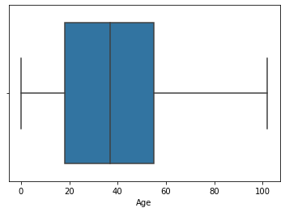

```python
# Review the Age data after cleaning
print(df_c['Age'].value_counts().sort_index())
sns.boxplot(x=df_c['Age'])
plt.show()
```

Great! let's go for next column and have a look

### Neighbourhood

```python
df_c['Neighbourhood'].value_counts(ascending=False)
```

```
JARDIM CAMBURI                 7717
MARIA ORTIZ                    5805
RESISTÊNCIA                    4430
JARDIM DA PENHA                3877
ITARARÉ                        3514
                               ...
ILHA DO BOI                      35
ILHA DO FRADE                    10
AEROPORTO                         8
ILHAS OCEÂNICAS DE TRINDADE       2
PARQUE INDUSTRIAL                 1
Name: Neighbourhood, Length: 81, dtype: int64
```

```python
df_c['Neighbourhood'].nunique()
```

```
81
```

From above, Neighbourhood data seems to be ok. will go for next

### Scholarship, Hypertenion, Diabetes, Alcoholism and SMS_received

For better Data understanding, will change the 1 and 0 values into yes or no for these 5 columns.

First, will rename Hipertension into Hypertension as it seems to be mis-typo

```python
df_c.rename(columns={'Hipertension':'Hypertension'}, inplace=True)
```

```python
#create a list for thses columns
cols=['Scholarship', 'Hypertension', 'Diabetes', 'Alcoholism', 'SMS_received']
```

```python
#apply check point in order to review after data changing
for p in cols:
    print(df_c[p].value_counts())
```

```
0    99655
1    10861
Name: Scholarship, dtype: int64
0    88716
1    21800
Name: Hypertension, dtype: int64
0    102573
1      7943
Name: Diabetes, dtype: int64
0    107156
1      3360
Name: Alcoholism, dtype: int64
0    75035
1    35481
Name: SMS_received, dtype: int64
```

```python
# Apply the changes to
for i in cols:
    df_c[i]=df_c[i].astype(str)
    df_c[i]=df_c[i].str.replace('0', 'No')
    df_c[i]=df_c[i].str.replace('1', 'Yes')
```

Let's check how our data now looks

```python
df_c.head()
```

|  | PatientId | AppointmentID | Gender | schedule_weekday | schedule_date | Days_diff | Age | Neighbourhood | Scholarship | Hypertension | Diabetes | Alcoholism | Handcap | SMS_received | No-show |
| --- | --- | --- | --- | --- | --- | --- | --- | --- | --- | --- | --- | --- | --- | --- | --- |
| 0 | 29872499824296 | 5642903 | F | Friday | 2016-04-29 | 0 | 62 | JARDIM DA PENHA | No | Yes | No | No | 0 | No | No |
| 1 | 558997776694438 | 5642503 | M | Friday | 2016-04-29 | 0 | 56 | JARDIM DA PENHA | No | No | No | No | 0 | No | No |
| 2 | 4262962299951 | 5642549 | F | Friday | 2016-04-29 | 0 | 62 | MATA DA PRAIA | No | No | No | No | 0 | No | No |
| 3 | 867951213174 | 5642828 | F | Friday | 2016-04-29 | 0 | 8 | PONTAL DE CAMBURI | No | No | No | No | 0 | No | No |
| 4 | 8841186448183 | 5642494 | F | Friday | 2016-04-29 | 0 | 56 | JARDIM DA PENHA | No | Yes | Yes | No | 0 | No | No |

```python
# Review after data changing
for p in cols:
    print(df_c[p].value_counts())
```

```
No     99655
Yes    10861
Name: Scholarship, dtype: int64
No     88716
Yes    21800
Name: Hypertension, dtype: int64
No     102573
Yes      7943
Name: Diabetes, dtype: int64
No     107156
Yes      3360
Name: Alcoholism, dtype: int64
No     75035
Yes    35481
Name: SMS_received, dtype: int64
```

Data have been changed successfully and counts have been affected. will go for next column.

### Handicap

```python
df_c['Handcap'].value_counts()
```

```
0    108281
1      2036
2       183
3        13
4         3
Name: Handcap, dtype: int64
```

data seems to be ok in that form. the only minor issue is the column name is mistypo. so will rename to Handicap.

```python
df_c.rename(columns={'Handcap':'Handicap'}, inplace=True)
```

```python
#check data after renaming
df_c['Handicap'].value_counts()
```

```
0    108281
1      2036
2       183
3        13
4         3
Name: Handicap, dtype: int64
```

### No-show

For better Data understanding, will change the 1 and 0 values into Show and No-Show. in addition will rename coulmns to Show for easier coding issue.

```python
df_c['No-show'].value_counts()
```

```
No     88205
Yes    22311
Name: No-show, dtype: int64
```

```python
# rename column to Show
df_c.rename(columns={'No-show':'Show'}, inplace=True)
```

```python
#replace values to Show and No-Show
df_c['Show'].replace('No', value='Show', inplace=True)
df_c['Show'].replace('Yes', value='No-Show', inplace=True)
```

```python
df_c['Show'].value_counts()
```

```
Show       88205
No-Show    22311
Name: Show, dtype: int64
```

Let's Have a loot of our data after cleaning

```python
df_c.shape
```

```
(110516, 15)
```

```python
df_c.info()
```

```
<class 'pandas.core.frame.DataFrame'>
Int64Index: 110516 entries, 0 to 110526
Data columns (total 15 columns):
 #   Column            Non-Null Count   Dtype
---  ------            --------------   -----
 0   PatientId         110516 non-null  object
 1   AppointmentID     110516 non-null  object
 2   Gender            110516 non-null  object
 3   schedule_weekday  110516 non-null  object
 4   schedule_date     110516 non-null  object
 5   Days_diff         110516 non-null  int16
 6   Age               110516 non-null  int64
 7   Neighbourhood     110516 non-null  object
 8   Scholarship       110516 non-null  object
 9   Hypertension      110516 non-null  object
 10  Diabetes          110516 non-null  object
 11  Alcoholism        110516 non-null  object
 12  Handicap          110516 non-null  int64
 13  SMS_received      110516 non-null  object
 14  Show              110516 non-null  object
dtypes: int16(1), int64(2), object(12)
memory usage: 12.9+ MB
```

```python
df_c.nunique()
```

```
PatientId            62296
AppointmentID       110516
Gender                   2
schedule_weekday         6
schedule_date          111
Days_diff              129
Age                    102
Neighbourhood           81
Scholarship              2
Hypertension             2
Diabetes                 2
Alcoholism               2
Handicap                 5
SMS_received             2
Show                     2
dtype: int64
```

> **Important Note:** From above, the Ptient ID unique Values is almost have the total values and that is because repetitive visits to the Hospital by the same Patient. So will drop the duplicated Patient ID into new dataframe and will keep the above cleaned dataframe is some investigations will be related to Patient himself and some other investigation will be related to the total values of Appointment ID.

### PatientId:

Will drop the duplicated Values into New Data Frame.

```python
df_c_patient=df_c.drop_duplicates(subset = ['PatientId'])
```

```python
df_c_patient.info()
```

```
<class 'pandas.core.frame.DataFrame'>
Int64Index: 62296 entries, 0 to 110524
Data columns (total 15 columns):
 #   Column            Non-Null Count  Dtype
---  ------            --------------  -----
 0   PatientId         62296 non-null  object
 1   AppointmentID     62296 non-null  object
 2   Gender            62296 non-null  object
 3   schedule_weekday  62296 non-null  object
 4   schedule_date     62296 non-null  object
 5   Days_diff         62296 non-null  int16
 6   Age               62296 non-null  int64
 7   Neighbourhood     62296 non-null  object
 8   Scholarship       62296 non-null  object
 9   Hypertension      62296 non-null  object
 10  Diabetes          62296 non-null  object
 11  Alcoholism        62296 non-null  object
 12  Handicap          62296 non-null  int64
 13  SMS_received      62296 non-null  object
 14  Show              62296 non-null  object
dtypes: int16(1), int64(2), object(12)
memory usage: 7.2+ MB
```

**Perfect 👌** Now we are ready for Exploratory Data Analysis and Visualization

*Keep in Mind:*We have 2 dataframes we will use during our investigation (df_c and df_c_patient).

## Exploratory Data Analysis

##### Go Home 🏠

For more easier coding, will add plotting functions as some data investigation will have the same type of plotting and data type. so will add *def* Functions.

```python
#This function for plotting a Pie Shape Plot with Percentage and Show frequency values
def pie_plot(df_x, column, title):
    explode=[0.05]*df_x[column].nunique()
    df_x[column].value_counts().plot.pie(explode=explode, autopct='%1.1f%%',shadow=True,figsize=(10,8), legend=True)
    plt.title(title)
    plt.show()
    print(df_x[column].value_counts());
```

```python
#this function for plotting different shape and type of columns based on Show and No Show values

def plot_col(df_x, column, title1, title2, title3):
    fig = plt.figure(figsize=(15,55))
    sns.set_style('whitegrid')

    explode=[0.05]*df_x[column].nunique()
    print(df_x[column].value_counts())
    df_x[column].value_counts().plot.pie(explode=explode, autopct='%1.1f%%',shadow=True,figsize=(10,8), legend=True)
    plt.title(title1)
    plt.show()


    print(df_x.groupby(['Show',column]).size())
    df_x.groupby(['Show',column]).size().sort_values().plot.bar(color=['tab:blue', 'tab:orange'], legend=False, rot=90);
    plt.title(title2)
    plt.ylabel=('Frequency')
    plt.show()


    new_df = df_x.groupby(column)['Show'].value_counts(normalize=True)
    new_df = new_df.mul(100).rename('Percent').reset_index().sort_values(column)
    g = sns.catplot(x=column, y='Percent', hue='Show', kind='bar', data=new_df)
    g.ax.set_ylim(0,100)
    g.fig.subplots_adjust(top=0.9)
    g.fig.suptitle(title3)
    print( new_df['Percent'])
```

### Research Question 1 (in General, regardless all other values, plot the percentage of Show and No-Show frequency!)

##### Go Home 🏠

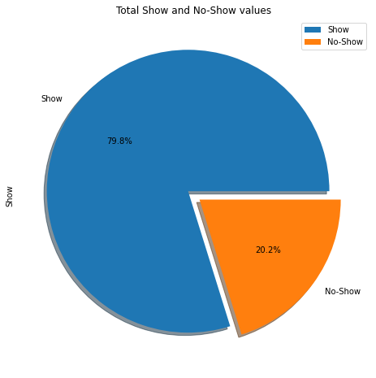

```
Show       88205
No-Show    22311
Name: Show, dtype: int64
```

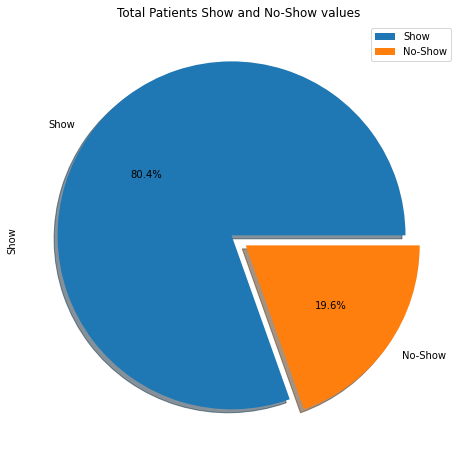

```
Show       50105
No-Show    12191
Name: Show, dtype: int64
```

```python
#plot frequency of shoe and now show values
pie_plot(df_c, 'Show', 'Total Show and No-Show values');
pie_plot(df_c_patient, 'Show', 'Total Patients Show and No-Show values');
```

> *From above Pie Chart, in general, almost 20% of Patients No Show at their Scheduled Day Appointment. Next, will investigate more data.*

### Research Question 2 (How The Gender Type impacts the Show and No Show Frequency and Percentage!)

##### Go Home 🏠

For the Gender Variable, it is more related to the Patient not the Appointment. so we will use the Dataframe filtered by unique patient for that investigation.

```
F    40043
M    22253
Name: Gender, dtype: int64
```

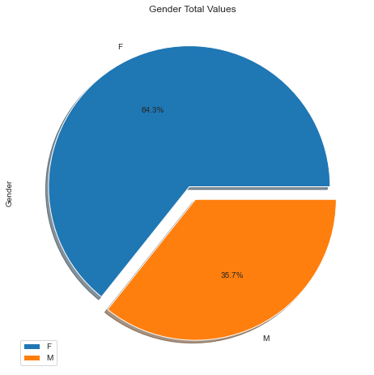

```
Show     Gender
No-Show  F          7827
         M          4364
Show     F         32216
         M         17889
dtype: int64
```

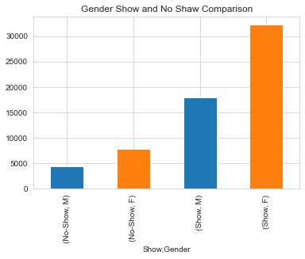

```
0    80.453512
1    19.546488
2    80.389161
3    19.610839
Name: Percent, dtype: float64
```

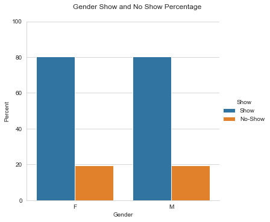

```python
plot_col(df_c_patient, 'Gender', 'Gender Total Values', 'Gender Show and No Shaw Comparison', 'Gender Show and No Show Percentage');
```

> From above Plots, we can see that:
> - Total Number of Females applying for Medical check more than Males (64.3% Females and 35.7% Males)
> - Percentage of Males and Females No Show at Scheduled Day almost the same(20%), it is the same percentage of the total Show and No Show Percentage proved at Question1

> So we will conclude at the truth of, the Gender does't affect the Show and No Show percentage but affecting the Show and No Show Frequency as the Females has more impacts.

### Research Question3 (How The Scheduled Weekday impacts the Show and No Show Frequency and Percentage!)

##### Go Home 🏠

For The Scheduled Day, it is related to the date not the patient. So, we will use the dataframe df_c.

```
Tuesday      26167
Wednesday    24259
Monday       23081
Friday       18914
Thursday     18071
Saturday        24
Name: schedule_weekday, dtype: int64
```

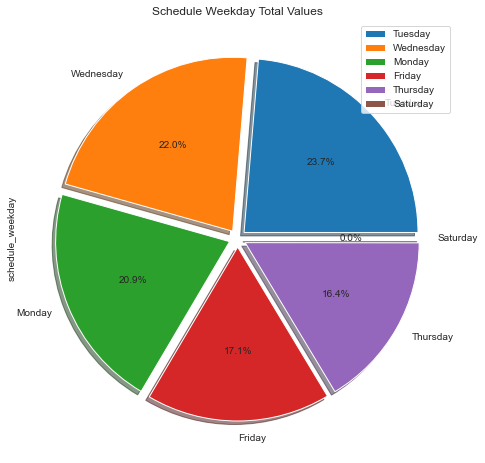

```
Show     schedule_weekday
No-Show  Friday               3886
         Monday               4559
         Saturday                1
         Thursday             3699
         Tuesday              5290
         Wednesday            4876
Show     Friday              15028
         Monday              18522
         Saturday               23
         Thursday            14372
         Tuesday             20877
         Wednesday           19383
dtype: int64
```

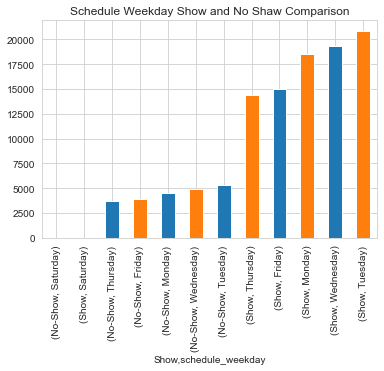

```
0     79.454372
1     20.545628
2     80.247823
3     19.752177
4     95.833333
5      4.166667
6     79.530740
7     20.469260
8     79.783697
9     20.216303
10    79.900243
11    20.099757
Name: Percent, dtype: float64
```

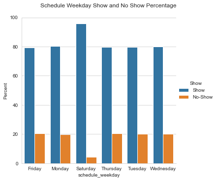

```python
plot_col(df_c, 'schedule_weekday', 'Schedule Weekday Total Values', 'Schedule Weekday Show and No Shaw Comparison', 'Schedule Weekday Show and No Show Percentage');
```

> From above Plots, we can see that:
> - Tuesday has the most number of Scheduled day reservations and has the highest Number of Patients Show for medical check
> - No appointments at Sunday, most probably it is NA by the hospital itself
> - Staurday has the lower percentage of patients No Show However it has the lowest number of Scheduled reservation.
> - The 5 other days has almost the same percentage of No Show as the same as the overall percentage of Show and No Show percentage

### Research Question 4 (How the Days difference between Appointment Day and Scheduled Day impacts the Show and No Show Frequency and Percentage!)

##### Go Home 🏠

```
Show     Days_diff
Show     0            36769
         2             5123
         1             4100
         4             4059
         7             3597
                      ...
         110              1
No-Show  169              1
         151              1
         146              1
         132              1
Length: 235, dtype: int64
```

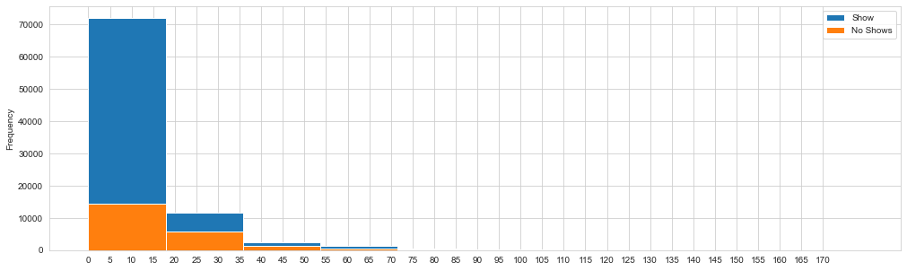

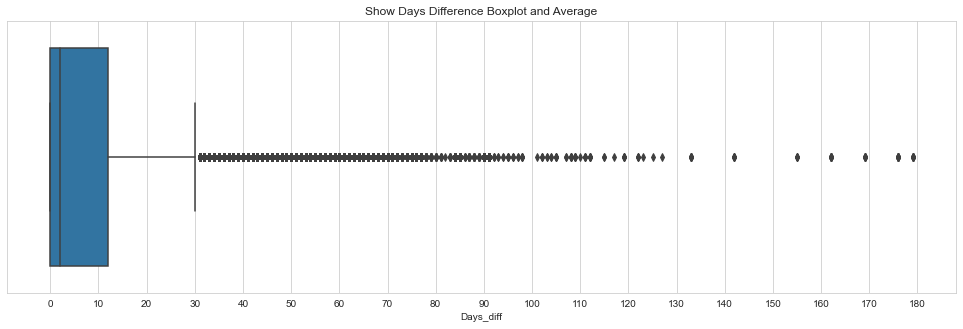

```
Average Days Difference of No Show =8.754787143585965
```

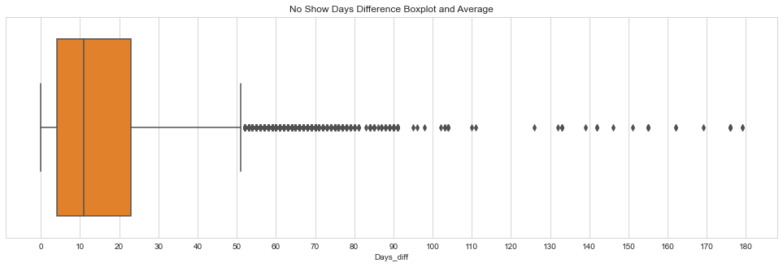

```
Average Days Difference of No Show =15.835641611761014
```

```python
print(df_c.groupby(['Show', 'Days_diff']).size().sort_values(ascending=False))

Show = (df_c.Show == 'Show')
No_Show = (df_c.Show == 'No-Show')

df_c[Show].Days_diff.plot.hist(figsize=(17,5))
df_c[No_Show].Days_diff.plot.hist()
plt.legend(['Show', 'No Shows'])
plt.xticks(np.arange(0, 175, 5.0))
plt.show()

fig, ax = pyplot.subplots(figsize=(17,5))
plt.xticks(np.arange(0, 185, 10.0))
sns.boxplot(x=df_c[Show].Days_diff)
plt.title('Show Days Difference Boxplot and Average')
plt.show()
print('Average Days Difference of No Show ={}'.format(df_c[Show].Days_diff.mean()))

fig, ax = pyplot.subplots(figsize=(17,5))
plt.xticks(np.arange(0, 185, 10.0))
sns.boxplot(x=df_c[No_Show].Days_diff, color='tab:orange')
plt.title('No Show Days Difference Boxplot and Average')
plt.show()
print('Average Days Difference of No Show ={}'.format(df_c[No_Show].Days_diff.mean()))
```

> From above Plot and data, we can see that:
> - There are a lot of Outliers values
> - The less Waiting Days for Appointment, the Highest Frequency for Patients to Show
> - Average Days Difference of Show at appointment is about 9 days
> - Average Days Difference of No Show at appointment is about 15 days

### Research Question 5 (Highest City has the Most Show!)

##### Go Home 🏠

We will explore the data for the City with the Highest Show Number at both dataframes the cleaned dataframe and the dataframe filtered by patient ID as it could give different output.

```python
print(df_c.groupby(['Neighbourhood', 'Show']).size().sort_values(ascending=False))
print(df_c_patient.groupby(['Neighbourhood', 'Show']).size().sort_values(ascending=False))
```

```
Neighbourhood                Show
JARDIM CAMBURI               Show       6252
MARIA ORTIZ                  Show       4586
RESISTÊNCIA                  Show       3525
JARDIM DA PENHA              Show       3246
SANTA MARTHA                 Show       2635
                                        ...
ILHA DO BOI                  No-Show       3
ILHAS OCEÂNICAS DE TRINDADE  No-Show       2
ILHA DO FRADE                No-Show       2
PARQUE INDUSTRIAL            Show          1
AEROPORTO                    No-Show       1
Length: 160, dtype: int64
Neighbourhood                Show
JARDIM CAMBURI               Show       3421
MARIA ORTIZ                  Show       2647
JARDIM DA PENHA              Show       2010
RESISTÊNCIA                  Show       1904
ITARARÉ                      Show       1616
                                        ...
ILHAS OCEÂNICAS DE TRINDADE  No-Show       2
PARQUE INDUSTRIAL            Show          1
ILHA DO FRADE                No-Show       1
ILHA DO BOI                  No-Show       1
AEROPORTO                    No-Show       1
Length: 160, dtype: int64
```

> From above Plot and data, we can see that:
> - JARDIM CAMURI City have the highest Show at Scheduled Day and the Highest Number of Unique Patient.

### Research Question 6 (How Scholarship impacts the Show and No Show Frequency and Percentage!)

**Note:** As Scholarship is unique for the Patient Status, So better to use the Dataframe filtered by unique Patient ID (df_c_patient)

```
No     56508
Yes     5788
Name: Scholarship, dtype: int64
```

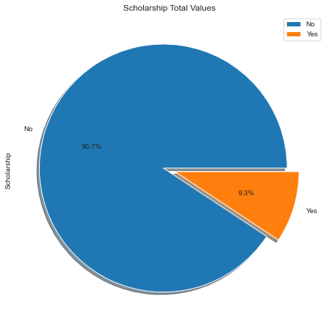

```
Show     Scholarship
No-Show  No             10884
         Yes             1307
Show     No             45624
         Yes             4481
dtype: int64
```

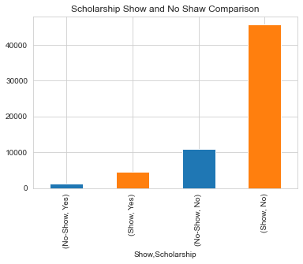

```
0    80.739010
1    19.260990
2    77.418798
3    22.581202
Name: Percent, dtype: float64
```

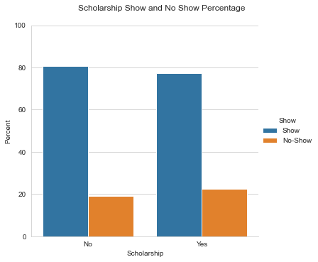

```python
plot_col(df_c_patient, 'Scholarship', 'Scholarship Total Values', 'Scholarship Show and No Shaw Comparison', 'Scholarship Show and No Show Percentage');
```

### Research Question 7 (How Diseases impacts the Show and No Show Frequency and Percentage!)

##### Go Home 🏠

**Note:** As Diseases is unique Variable for the Patient Status, So better to use the Dataframe filtered by unique Patient ID (df_c_patient)

#### Hypertenstion:

```
No     50055
Yes    12241
Name: Hypertension, dtype: int64
```

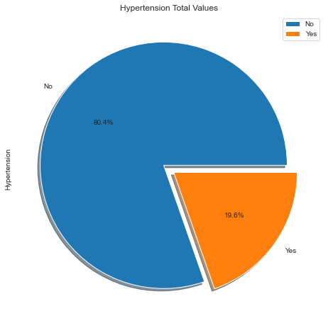

```
Show     Hypertension
No-Show  No              10172
         Yes              2019
Show     No              39883
         Yes             10222
dtype: int64
```

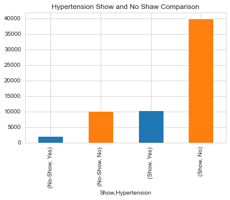

```
0    79.678354
1    20.321646
2    83.506249
3    16.493751
Name: Percent, dtype: float64
```

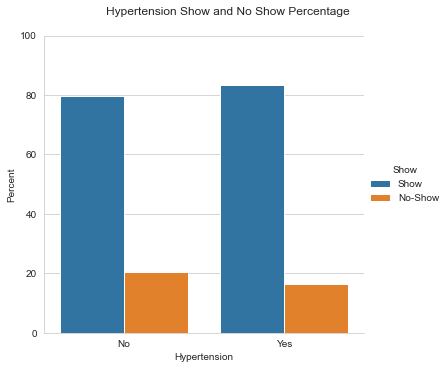

```python
plot_col(df_c_patient, 'Hypertension', 'Hypertension Total Values', 'Hypertension Show and No Shaw Comparison', 'Hypertension Show and No Show Percentage');
```

> From above Plots, we can see that:
> - The percentage of Patients with Hypertention is 19.6%. Number of Patients having Hypertension is 12241
> - The percentage of Patients having Hypertension show at appointment is a bit higher than patients Doesn't have

#### Diabetes:

```
No     57880
Yes     4416
Name: Diabetes, dtype: int64
```

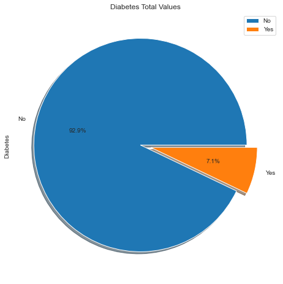

```
Show     Diabetes
No-Show  No          11431
         Yes           760
Show     No          46449
         Yes          3656
dtype: int64
```

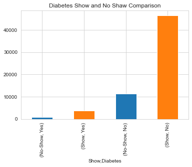

```
0    80.250518
1    19.749482
2    82.789855
3    17.210145
Name: Percent, dtype: float64
```

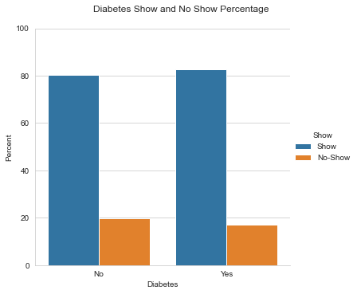

```python
plot_col(df_c_patient, 'Diabetes', 'Diabetes Total Values', 'Diabetes Show and No Shaw Comparison', 'Diabetes Show and No Show Percentage');
```

> From above Plots, we can see that:
> - The percentage of Patients with Diabetes is 7%. Number of Patients having Diabetesis 4416
> - The percentage of Patients having Diabetes show at appointment is a bit higher than patients Doesn't have

**Note:** Since some Patients can have both Diabetes and Hypertension, So will have a bit more investigation in that issue.

```
Show     Hypertension  Diabetes
Show     No            No          39221
No-Show  No            No          10001
Show     Yes           No           7228
                       Yes          2994
No-Show  Yes           No           1430
Show     No            Yes           662
No-Show  Yes           Yes           589
         No            Yes           171
dtype: int64
```

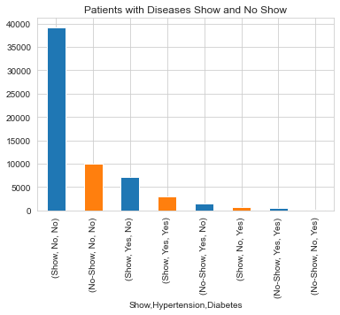

```python
df_c_patient.groupby(['Show', 'Hypertension', 'Diabetes']).size().sort_values(ascending=False).plot.bar(color=['tab:blue', 'tab:orange'], rot=90, title='Patients with Diseases Show and No Show');
df_c_patient.groupby(['Show', 'Hypertension', 'Diabetes']).size().sort_values(ascending=False)
```

> From above:
> - The Patients with no diseases has the highest Show frequency.
> - The Patients Diabetes only has the Lowest Show Frquency
> - The Patients with Hypertension has the Highest Show Frequency of Patients with Diseas more than those who have Diabets or both

### Research Question 8 (Does Handicap Grades affects the Show status!)

##### Go Home 🏠

**Note:** As Handicap Status is unique Variable for the Patient Status, So better to use the Dataframe filtered by unique Patient ID (df_c_patient).

```
0    61164
1     1024
2       99
3        6
4        3
Name: Handicap, dtype: int64
```

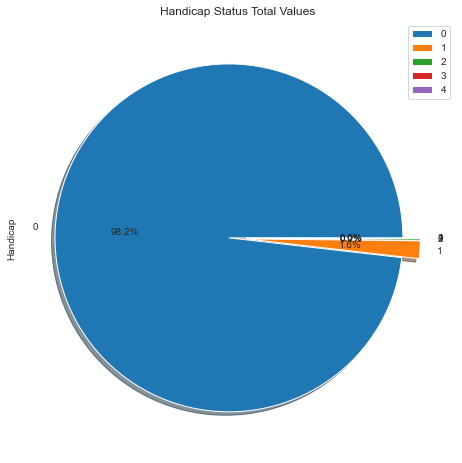

```
Show     Handicap
No-Show  0           12010
         1             159
         2              19
         3               2
         4               1
Show     0           49154
         1             865
         2              80
         3               4
         4               2
dtype: int64
```

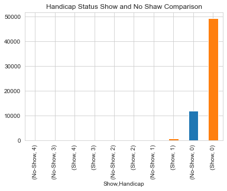

```
0    80.364267
1    19.635733
2    84.472656
3    15.527344
4    80.808081
5    19.191919
6    66.666667
7    33.333333
8    66.666667
9    33.333333
Name: Percent, dtype: float64
```

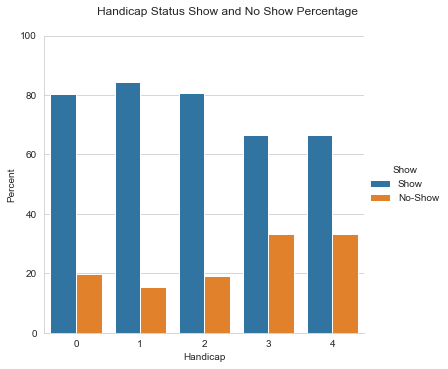

```python
plot_col(df_c_patient, 'Handicap', 'Handicap Status Total Values', 'Handicap Status Show and No Shaw Comparison', 'Handicap Status Show and No Show Percentage');
```

> From above:
> - The Patients with Handicap Status 1 have the heighst Show Percentage then Status 2 comes next

### Research Question 9 (How Alcoholism Status impacts the Show and No Show Frequency and Percentage!)

##### Go Home 🏠

**Note:** Alcoholism is aunique Variable for the Patient, So better to use the Dataframe filtered by unique Patient ID (df_c_patient)

```
No     60790
Yes     1506
Name: Alcoholism, dtype: int64
```

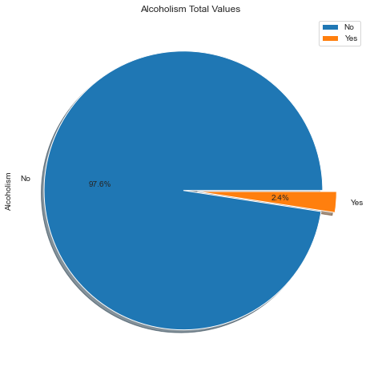

```
Show     Alcoholism
No-Show  No            11845
         Yes             346
Show     No            48945
         Yes            1160
dtype: int64
```

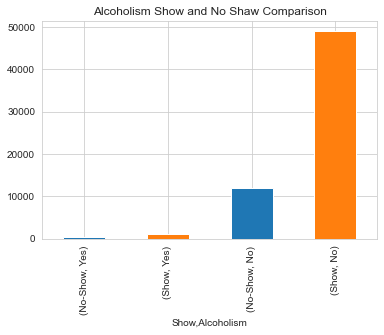

```
0    80.514887
1    19.485113
2    77.025232
3    22.974768
Name: Percent, dtype: float64
```

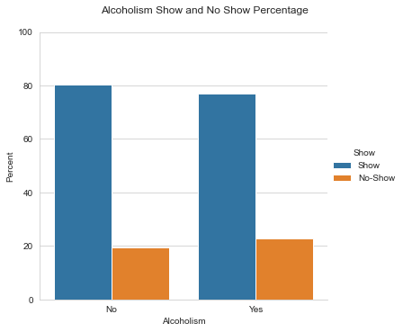

```python
plot_col(df_c_patient, 'Alcoholism', 'Alcoholism Total Values', 'Alcoholism Show and No Shaw Comparison', 'Alcoholism Show and No Show Percentage');
```

> From above:
> - Number of Alcoholic Patients is 1506 with about 2.4% of total Patients
> - Percentage of Alcoholic Patients Show at Scheduled Day is lower Than percentage of Non-Alcoholic